# hmwave_demo_0

# History matching a toy model in waves

History matching process (for each separate output):

1. generate initial design
2. generate a target point
3. generate a uniform sample (for visulasation and calculating space sizes)

for each output:  
- run the model at the design points  
- run the model at the target point  
- fit a dicekriging km() to each output  
- calculate the implausibility of each point in the uniform sample  
- calculate the implausibility of each point in the augmented lhs  
- return the model fit and some fit statistics, both sets of implausibility calculations, and the new design

## Load packages and helper functions

```r
library(lhs)
library(DiceKriging)
source('https://raw.githubusercontent.com/dougmcneall/packages-git/5f79ffe749f25c6fc39f4f7925e1538d36b7caf1/emtools.R')
source('https://raw.githubusercontent.com/dougmcneall/packages-git/5f79ffe749f25c6fc39f4f7925e1538d36b7caf1/imptools.R')
source('https://raw.githubusercontent.com/dougmcneall/packages-git/5f79ffe749f25c6fc39f4f7925e1538d36b7caf1/vistools.R')

source('hmwave_demo_0.fun.R')
```

### initial design

Set up an initial design, sampling sparsely from the input domain (as if the model was expensive to run).  
Experiment with n (initial design points), n.app (number of points to augment the design with in each wave), and uncertainty budget.

```r
n = 10 # number of initial design points
k = 4  # number of model inputs
d = 3  # number of model outputs

# simplest method is to choose a subset of the discovered NROY
# points to append to the design

n.app = 10 # number of points to append

X = maximinLHS(n, k = k,dup = 2)
colnames(X) <- c('x1', 'x2', 'x3', 'x4')

#X.target = matrix(runif(4), nrow = 1) # uncomment this and comment the next line for a random target input.
X.target = matrix(rep(0.5,4), nrow = 1)

# run the model outside of the function
#Y = run.model(X)
#Y.target = run.model(X.target)
```

## Run the toy model

Three test functions from the [Virtual Library of Simulation Experiments](https://www.sfu.ca/~ssurjano/) are combined together to make multivariate output. The key is that all the functions use all four inputs in different ways, and each model produces a single deterministic output.

```r
Y.raw = run.model(X)
# Mean and standard deviation of the raw output

print(c('Output mean = ', c(round(apply(Y.raw ,2, mean),2))))
```

```
##                                y1               y2               y3
## "Output mean = "          "11.56"           "7.62"           "2.33"
```

```r
print(c('Output SD = ', round(apply(Y.raw,2,sd),2)))
```

```
##                            y1             y2             y3
## "Output SD = "         "4.51"          "4.2"         "1.27"
```

```r
Y.target.raw = run.model(X.target)

print(c('Output target = ', round(Y.target.raw),2))
```

```
## [1] "Output target = " "12"               "7"
## [4] "2"                "2"
```

```r
Y.all.norm = normalize(rbind(Y.raw, Y.target.raw))
Y = Y.all.norm[1:n, ]
Y.target = matrix(Y.all.norm[n+1, ], nrow = 1)

print(c('Normalised output mean = ', round(apply(Y.all.norm ,2, mean),2)))
```

```
##                                                      y1
## "Normalised output mean = "                      "0.48"
##                          y2                          y3
##                      "0.48"                      "0.37"
```

```r
print(c('Normalised output SD = ', round(apply(Y.all.norm,2,sd),2)))
```

```
##                                                  y1
## "Normalised output SD = "                    "0.34"
##                        y2                        y3
##                    "0.32"                    "0.33"
```

```r
print(c('Output target = ', round(Y.target,2)))
```

```
## [1] "Output target = " "0.51"             "0.47"
## [4] "0.31"
```

```r
# The standard deviation of the model output is approximately [5,5,1] and the
# mean is around [12,8,2]

# With a small number of design points, the target is often at one of the margins of the normalised space
```

### Model output

The model input is 4 dimensional and output is 3 dimensional, which is hard to visualise. This is what happens when you can run the model as many times as you like, and vary the inputs one-at-a-time.

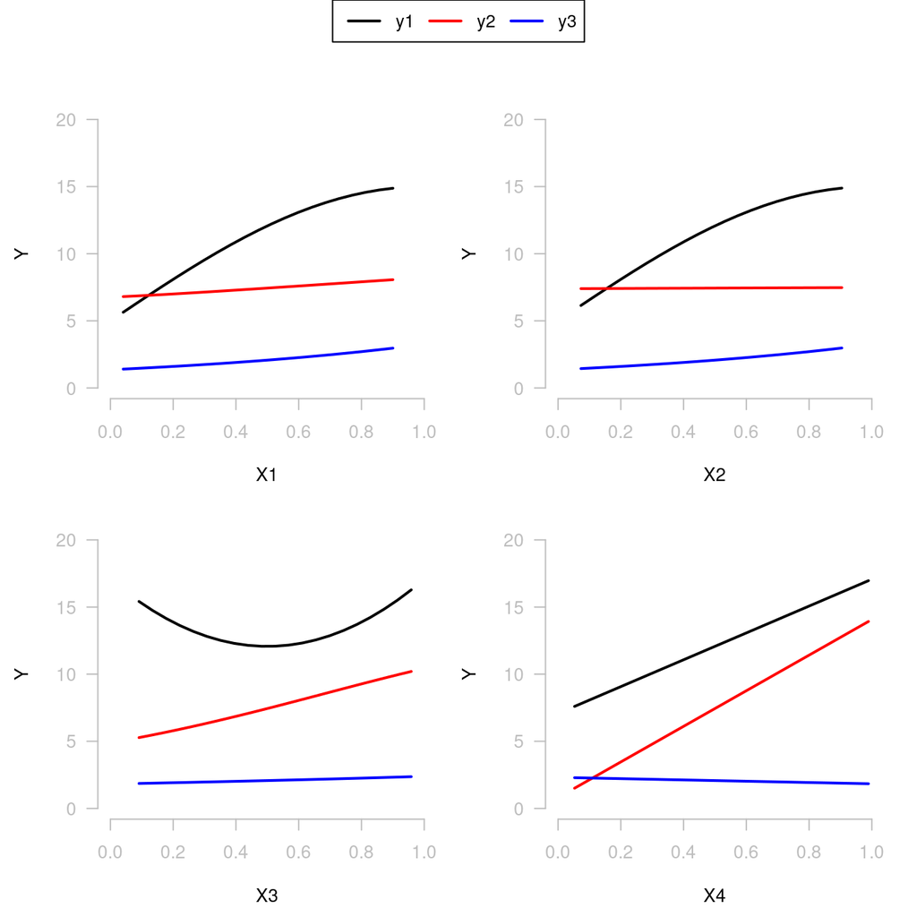

```r
n.sens = 21
X.oaat = oaat.design(X, n.sens, hold = X.target)
Y.oaat = run.model(X.oaat)
linecols = c('black', 'red', 'blue')


ylim = c(0,1)
xlim = c(0,1)

par(mfrow = c(2,2), mar = c(4,4,2,1), oma = c(0.5,0.5, 3, 0.5))
ndat = ncol(Y.oaat)
d = ncol(X.oaat)
for(i in 1:d){
  ix = seq(from = ((i*n.sens) - (n.sens-1)), to =  (i*n.sens), by = 1)
  plot(X.oaat[ix,i], Y.oaat[ix,2],
       type = 'n',
       ylab= 'Y', axes = FALSE,
       main = '',
       xlab = paste0('X',i),
       xlim = c(0,1), ylim = c(0,20))

  for(j in 1:ndat){

    y.oaat = Y.oaat[ix,j]
    lines(X.oaat[ix,i],y.oaat, col = linecols[j], lwd = 2)
  }
  axis(1, col = 'grey', col.axis = 'grey', las = 1, title = 'X')
  axis(2, col = 'grey', col.axis = 'grey', las = 1)
 # mtext(3, text = colnames(lhs)[i], line = 0.2, cex = 0.7)
}
reset()
legend('top',
       legend = colnames(Y),
       col = linecols,
       cex = 0.8,
       lwd = 2,
       horiz = TRUE)
```

```r
#dev.off()
```

```r
# Assume the entire uncertainty budget is in the observational uncertainty initially
#obs.sd.list = list(0.013,0.013,0.013)
obs.sd.list = list(0.01,0.01,0.01)
disc.list = list(0,0,0)
disc.sd.list = list(0, 0, 0)

thres = 3   # implausibility threshold

mins.aug = rep(0,4)
maxes.aug = rep(1,4)

# Improvements to the above function from Andrianakis et al. (2015)
# 1) Reduce the range the emulator is fit over, as the waves continue.
# 2) Sample candidate design points from NEAR the existing NROY design points.
```

## Do the History matching in 6 waves

```r
# This function augments the original design with points that are
# found to be NROY using the emulator. It samples uniformly across the original space,
# and then keeps n.aug points.
wave1 = add.nroy.design.points(X = X,
                               Y = Y,
                               Y.target = Y.target,
                               n.aug = 100000,
                               mins.aug = mins.aug,
                               maxes.aug = maxes.aug,
                               thres = 3,
                               disc.list=disc.list,
                               disc.sd.list = disc.sd.list,
                               obs.sd.list = obs.sd.list)

# This part excludes any original design points outside of the ranges returned as NROY by
# add.nroy.design.points. This shrinks down the domain that the emulator
# is fit over.
keep1.ix = which(apply(X, FUN = WithinRange,1,
                      maxes = wave1$X.nroy.max,
                      mins = wave1$X.nroy.min))

# This part takes the n.aug points found to be NROY, and chooses n.app of them that are found to be
# furthest apart. These are appended to the design points that are inside the marginal NROY ranges.
X2 = rbind(X[keep1.ix, ] , ChooseMaximinNroy(n.app = n.app, waveobj=wave1, nreps = 10000))

# Run the model at the new design
Y2.raw = run.model(X2)

# Normalise with respect to the original output.
Y2 = normalize(Y2.raw, wrt = Y.raw)

wave2 = add.nroy.design.points(X = X2,
                               Y = Y2,
                               Y.target = Y.target,
                               n.aug = 50000,
                               mins.aug = wave1$X.nroy.min,
                               maxes.aug = wave1$X.nroy.max,
                               thres = 3,
                               disc.list = disc.list,
                               disc.sd.list = disc.sd.list,
                               obs.sd.list = obs.sd.list)

keep2.ix = which(apply(X2, FUN = WithinRange,1,
                       maxes = wave2$X.nroy.max,
                       mins = wave2$X.nroy.min))

X3 = rbind(X2[keep2.ix, ], ChooseMaximinNroy(n.app = n.app, waveobj=wave2, nreps = 10000))

Y3.raw = run.model(X3)
Y3 = normalize(Y3.raw, wrt = Y.raw)

wave3 = add.nroy.design.points(X = X3,
                               Y = Y3,
                               Y.target = Y.target,
                               n.aug = 50000,
                               mins.aug = wave2$X.nroy.min,
                               maxes.aug = wave2$X.nroy.max,
                               thres = 3,
                               disc.list = disc.list,
                               disc.sd.list = disc.sd.list,
                               obs.sd.list = obs.sd.list)

keep3.ix = which(apply(X3, FUN = WithinRange,1,
                       maxes = wave3$X.nroy.max,
                       mins = wave3$X.nroy.min))

X4 = rbind(X3[keep3.ix, ],
           ChooseMaximinNroy(n.app = n.app, waveobj=wave3, nreps = 10000))

Y4.raw = run.model(X4)
Y4 = normalize(Y4.raw, wrt = Y.raw)

wave4 = add.nroy.design.points(X = X4,
                               Y = Y4,
                               Y.target = Y.target,
                               n.aug = 30000,
                               mins.aug = wave3$X.nroy.min,
                               maxes.aug = wave3$X.nroy.max,
                               thres = 3,
                               disc.list = disc.list,
                               disc.sd.list = disc.sd.list,
                               obs.sd.list = obs.sd.list)

keep4.ix = which(apply(X4, FUN = WithinRange,1,
                       maxes = wave4$X.nroy.max,
                       mins = wave4$X.nroy.min))

X5 = rbind(X4[keep4.ix, ],
           ChooseMaximinNroy(n.app = n.app, waveobj=wave4, nreps = 10000))

Y5.raw = run.model(X5)
Y5 = normalize(Y5.raw, wrt = Y.raw)


wave5 = add.nroy.design.points(X = X5,
                               Y = Y5,
                               Y.target = Y.target,
                               n.aug = 30000,
                               mins.aug = wave4$X.nroy.min,
                               maxes.aug = wave4$X.nroy.max,
                               thres = 3,
                               disc.list = disc.list,
                               disc.sd.list = disc.sd.list,
                               obs.sd.list = obs.sd.list)

keep5.ix = which(apply(X5, FUN = WithinRange,1,
                       maxes = wave5$X.nroy.max,
                       mins = wave5$X.nroy.min))

X6 = rbind(X5[keep5.ix, ], ChooseMaximinNroy(n.app = n.app, waveobj=wave5, nreps = 10000))

Y6.raw = run.model(X6)
Y6 = normalize(Y6.raw, wrt = Y.raw)


wave6 = add.nroy.design.points(X = X6,
                               Y = Y6,
                               Y.target = Y.target,
                               n.aug = 30000,
                               mins.aug = wave5$X.nroy.min,
                               maxes.aug = wave5$X.nroy.max,
                               thres = 3,
                               disc.list = disc.list,
                               disc.sd.list = disc.sd.list,
                               obs.sd.list = obs.sd.list)
```

Idea: plot the design points in different colours

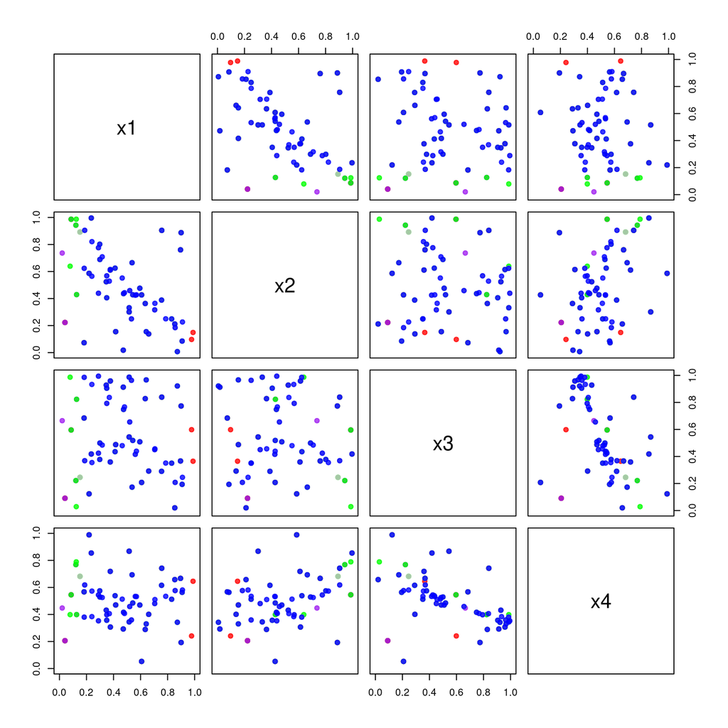

```r
allX = rbind(X, X2, X3, X4, X5, X6)
transp = 200

allX.cols = c(rep(makeTransparent('black',transp),nrow(X)),
         rep(makeTransparent('red',transp),nrow(X2)),
        rep(makeTransparent('purple',transp),nrow(X3)),
        rep(makeTransparent('green', transp),nrow(X4)),
       rep(makeTransparent('grey', transp),nrow(X5)),
       rep(makeTransparent('blue',transp),nrow(X6)))

pairs(allX, xlim = c(0,1), ylim = c(0,1), col = allX.cols, cex = 1, pch = 19)
```

### Visualize the results

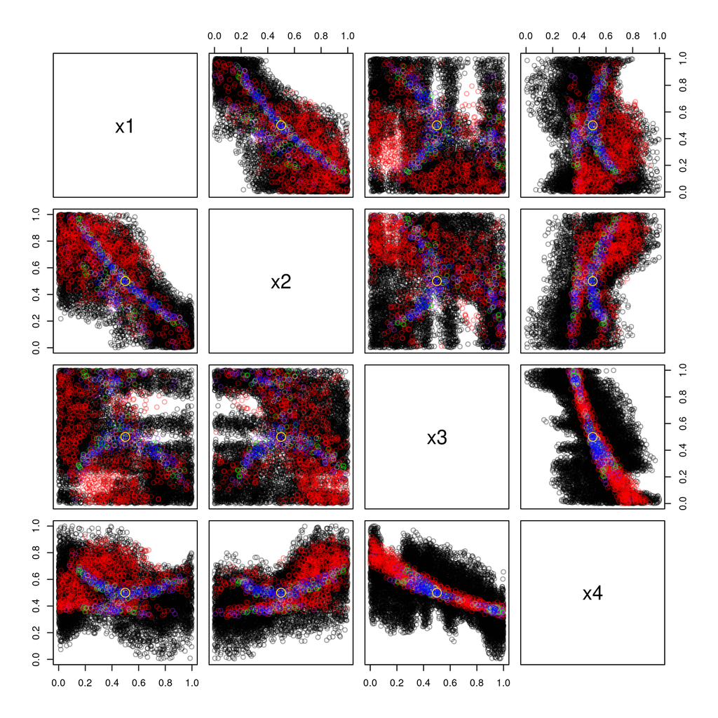

```r
all.nroy = rbind(wave1$X.nroy, wave2$X.nroy, wave3$X.nroy, wave4$X.nroy, wave5$X.nroy, wave6$X.nroy, X.target)

transp = 100

cols = c(rep(makeTransparent('black',transp),nrow(wave1$X.nroy)),
         rep(makeTransparent('red',transp),nrow(wave2$X.nroy)),
         rep(makeTransparent('purple',transp),nrow(wave3$X.nroy)),
         rep(makeTransparent('green', transp),nrow(wave4$X.nroy)),
         rep(makeTransparent('grey', transp),nrow(wave5$X.nroy)),
         rep(makeTransparent('blue',transp),nrow(wave6$X.nroy)),
          rep('gold', 1)

)
cex = c(rep(1, nrow(all.nroy)-1), 2)

pairs(all.nroy, xlim = c(0,1), ylim = c(0,1), col = cols, cex = cex, pch = 21)
```

How much does the volume of input space reduce with each wave?  
Very often we find no real gain (or even a degradation) after the first 3 waves.

This last bit isn’t right - I think the function draws from a smaller space each time so It’s not a fair comparison. Need a function that estimates the NROY proportion from the initial space - probably using importance sampling. Check other HM papers to see how this is done.

If each wave was a perfect subset, I think you could just multiply the NROY fractions together as you go.

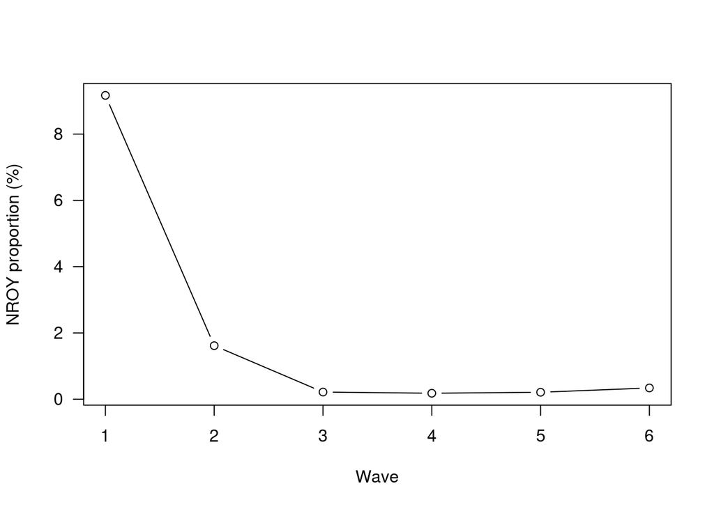

```r
waves_list = list(wave1, wave2, wave3, wave4 ,wave5, wave6)

GetNroyProp = function(waveobj){
  nrow(waveobj$X.nroy) / nrow(waveobj$X.aug)
}

wave.prop = lapply(waves_list, FUN = GetNroyProp)

par(las = 1)
plot(1:length(waves_list), c(wave.prop, recursive = TRUE) * 100, type = 'b',
     xlab = 'Wave', ylab = 'NROY proportion (%)')
```

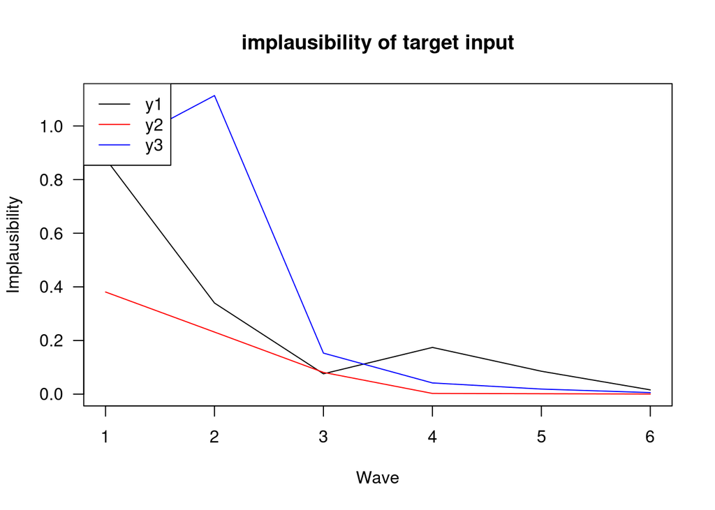

```r
# What is the implausibility of the genuine point?
# Apply this over the waves and see how it moves about

target.impl.mat = matrix(ncol = ncol(Y), nrow = length(waves_list))
colnames(target.impl.mat) <- colnames(Y)

for(j in 1:length(waves_list)){

 waveobj = waves_list[[j]]

 X.target.pred.list = lapply(waveobj$fit.list, FUN = 'predict', newdata =matrix(X.target, nrow = 1), type = 'UK')

  impl.row= NULL
  for(i in 1:length(X.target.pred.list)){

    pred.impl = impl(em = X.target.pred.list[[i]]$mean,
                     em.sd = X.target.pred.list[[i]]$sd,
                     disc = disc.list[[i]],
                     disc.sd = disc.sd.list[[i]],
                     obs = Y.target[[i]],
                     obs.sd = obs.sd.list[[i]])

    impl.row = cbind(impl.row, pred.impl)
  }

  target.impl.mat[j, ] = impl.row

}

par(las = 1)
matplot(target.impl.mat, type = 'l', lty = 'solid', xlab = 'Wave', ylab = 'Implausibility',
        col = c('black', 'red', 'blue'), main = 'implausibility of target input')
abline(h = 3, lty = 'dashed', col = 'grey')
legend('topleft', legend = c('y1','y2','y3'),lty = 'solid', col = c('black', 'red', 'blue'))
```

This is the implausibility of the (hidden) target input, as estimated by the emulator, through the waves. If the implausibility goes over the threshold (usually 3) at any point, something has gone wrong. It means your target point is being ruled out.